# **Loading the dataset**

The dataset consists of drive cycle power profile calculated for an electric Ford F150 truck with a 35kWh battery pack scaled for a single Panasonic 18650PF cell at 25 degree Celcius.

```python
import pandas as pd
```

```python
data = pd.read_csv('/content/drive/MyDrive/Colab Notebooks/Projects/SOC & SOE Estimation/Dataset/dataset_SOC.csv')
data
```

|  | Voltage (V) | Current (A) | Ah | Wh | Power (W) | Temp (C) | Time(s) | Chamber_Temp (C) |
| --- | --- | --- | --- | --- | --- | --- | --- | --- |
| 0 | 4.1819 | -0.01062 | 0.00000 | 0.00000 | -0.044412 | 25.619 | 0.00000 | 25 |
| 1 | 4.1806 | -0.05063 | 0.00000 | -0.00001 | -0.211660 | 25.619 | 0.09500 | 25 |
| 2 | 4.1799 | -0.06125 | 0.00000 | -0.00001 | -0.256020 | 25.418 | 0.19100 | 25 |
| 3 | 4.1793 | -0.06533 | 0.00000 | -0.00002 | -0.273030 | 25.418 | 0.29700 | 25 |
| 4 | 4.1793 | -0.06615 | -0.00001 | -0.00003 | -0.276460 | 25.429 | 0.39599 | 25 |
| ... | ... | ... | ... | ... | ... | ... | ... | ... |
| 116977 | 3.3534 | 0.00000 | -2.54960 | -8.63840 | 0.000000 | 27.480 | 11733.00000 | 25 |
| 116978 | 3.3534 | 0.00000 | -2.54960 | -8.63840 | 0.000000 | 27.480 | 11733.00000 | 25 |
| 116979 | 3.3534 | 0.00000 | -2.54960 | -8.63840 | 0.000000 | 27.480 | 11733.00000 | 25 |
| 116980 | 3.3527 | 0.00000 | -2.54960 | -8.63840 | 0.000000 | 27.267 | 11733.00000 | 25 |
| 116981 | 3.3527 | 0.00000 | -2.54960 | -8.63840 | 0.000000 | 27.267 | 11733.00000 | 25 |

116982 rows × 8 columns

# **Plots**

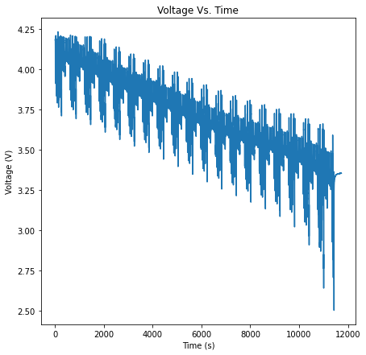

```python
import matplotlib.pyplot as plt
%matplotlib inline

plt.figure(figsize=(7,7))
plt.plot(data['Time(s)'], data['Voltage (V)'])
plt.title('Voltage Vs. Time')
plt.xlabel('Time (s)')
plt.ylabel('Voltage (V)')
plt.show()
```

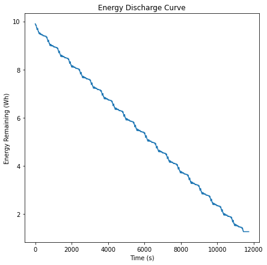

```python
plt.figure(figsize=(7,7))
plt.title('Energy Discharge Curve')
plt.xlabel('Time (s)')
plt.ylabel('Energy Remaining (Wh)')
plt.plot(data['Time(s)'], data['Wh']+9.9)
plt.show()
```

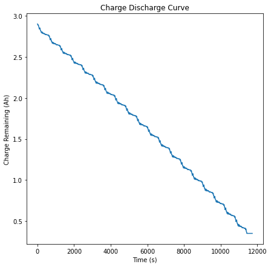

```python
plt.figure(figsize=(7,7))
plt.title('Charge Discharge Curve')
plt.xlabel('Time (s)')
plt.ylabel('Charge Remaining (Ah)')
plt.plot(data['Time(s)'], data['Ah']+2.9)
plt.show()
```

# **Dropping unnecessary columns**

For the estimation of SOC, we only require the volage, charging/ discharging current, and the temperature of the battery.

For the estimation of SOE, we will require volatage, chargin/ discharging current, temparature, and SOC.

```python
data.drop(['Power (W)', 'Time(s)', 'Chamber_Temp (C)'], axis=1, inplace=True)
data
```

|  | Voltage (V) | Current (A) | Ah | Wh | Temp (C) |
| --- | --- | --- | --- | --- | --- |
| 0 | 4.1819 | -0.01062 | 0.00000 | 0.00000 | 25.619 |
| 1 | 4.1806 | -0.05063 | 0.00000 | -0.00001 | 25.619 |
| 2 | 4.1799 | -0.06125 | 0.00000 | -0.00001 | 25.418 |
| 3 | 4.1793 | -0.06533 | 0.00000 | -0.00002 | 25.418 |
| 4 | 4.1793 | -0.06615 | -0.00001 | -0.00003 | 25.429 |
| ... | ... | ... | ... | ... | ... |
| 116977 | 3.3534 | 0.00000 | -2.54960 | -8.63840 | 27.480 |
| 116978 | 3.3534 | 0.00000 | -2.54960 | -8.63840 | 27.480 |
| 116979 | 3.3534 | 0.00000 | -2.54960 | -8.63840 | 27.480 |
| 116980 | 3.3527 | 0.00000 | -2.54960 | -8.63840 | 27.267 |
| 116981 | 3.3527 | 0.00000 | -2.54960 | -8.63840 | 27.267 |

116982 rows × 5 columns

# **Generating the target variables (SOC & SOE) from Amp-Hour & Watt-Hour discharging of the battery**

The given values in "Ah" column shows the amount of amp-hour discharge from the battery with time. So, by adding the nominal amp-hour i.e. 2.9Ah, to all the values and dividing it again by 2.9Ah we will get out our target variable, SOC.

Similarly, the given values in "Wh" column shows the amount of watt-hour discharge from the battery with time. Panasonic 18650PF has a maximum energy capacity of 9.9Wh. So, by adding the maximum energy capacity to all the values and dividing it again by 9.9Wh, we will get our other target variable, SOE.

```python
#Making sure that no column has missing values
data.info()
```

```
<class 'pandas.core.frame.DataFrame'>
RangeIndex: 116982 entries, 0 to 116981
Data columns (total 5 columns):
 #   Column       Non-Null Count   Dtype
---  ------       --------------   -----
 0   Voltage (V)  116982 non-null  float64
 1   Current (A)  116982 non-null  float64
 2   Ah           116982 non-null  float64
 3   Wh           116982 non-null  float64
 4   Temp (C)     116982 non-null  float64
dtypes: float64(5)
memory usage: 4.5 MB
```

```python
data['SOC'] = (data['Ah'] + 2.9)/2.9
data['SOE'] = (data['Wh']+9.9)/9.9
data.drop(['Ah', 'Wh'], axis=1, inplace=True)
data
```

|  | Voltage (V) | Current (A) | Temp (C) | SOC | SOE |
| --- | --- | --- | --- | --- | --- |
| 0 | 4.1819 | -0.01062 | 25.619 | 1.000000 | 1.000000 |
| 1 | 4.1806 | -0.05063 | 25.619 | 1.000000 | 0.999999 |
| 2 | 4.1799 | -0.06125 | 25.418 | 1.000000 | 0.999999 |
| 3 | 4.1793 | -0.06533 | 25.418 | 1.000000 | 0.999998 |
| 4 | 4.1793 | -0.06615 | 25.429 | 0.999997 | 0.999997 |
| ... | ... | ... | ... | ... | ... |
| 116977 | 3.3534 | 0.00000 | 27.480 | 0.120828 | 0.127434 |
| 116978 | 3.3534 | 0.00000 | 27.480 | 0.120828 | 0.127434 |
| 116979 | 3.3534 | 0.00000 | 27.480 | 0.120828 | 0.127434 |
| 116980 | 3.3527 | 0.00000 | 27.267 | 0.120828 | 0.127434 |
| 116981 | 3.3527 | 0.00000 | 27.267 | 0.120828 | 0.127434 |

116982 rows × 5 columns

# **Shuffling and splitting the data it into training and test sets**

```python
from sklearn.model_selection import train_test_split

# data = data.sample(frac=1)

Y_SOC = data['SOC']
Y_SOE = data['SOE']

X_SOC = data.drop(['SOC', 'SOE'], axis=1)
X_SOE = data.drop(['SOE'], axis=1)

X_train_SOC, X_test_SOC, Y_train_SOC, Y_test_SOC = train_test_split(X_SOC, Y_SOC, train_size=0.8, random_state=1)
X_train_SOE, X_test_SOE, Y_train_SOE, Y_test_SOE = train_test_split(X_SOE, Y_SOE, train_size=0.8, random_state=1)

X_train_SOC.reset_index(level=None, drop=True, inplace=True, col_level=0, col_fill='')
X_test_SOC.reset_index(level=None, drop=True, inplace=True, col_level=0, col_fill='')
Y_train_SOC.reset_index(level=None, drop=True, inplace=True)
Y_test_SOC.reset_index(level=None, drop=True, inplace=True)

X_train_SOE.reset_index(level=None, drop=True, inplace=True, col_level=0, col_fill='')
X_test_SOE.reset_index(level=None, drop=True, inplace=True, col_level=0, col_fill='')
Y_train_SOE.reset_index(level=None, drop=True, inplace=True)
Y_test_SOE.reset_index(level=None, drop=True, inplace=True)
```

```python
X_train_SOC
```

|  | Voltage (V) | Current (A) | Temp (C) |
| --- | --- | --- | --- |
| 0 | 3.3558 | -5.76610 | 27.502 |
| 1 | 3.8197 | -1.36620 | 27.312 |
| 2 | 4.0894 | 0.02613 | 27.290 |
| 3 | 3.5475 | -0.71046 | 27.301 |
| 4 | 3.6802 | 2.51700 | 27.088 |
| ... | ... | ... | ... |
| 93580 | 3.7740 | -0.07431 | 27.525 |
| 93581 | 3.4870 | -0.08003 | 28.556 |
| 93582 | 4.0777 | -0.85908 | 26.673 |
| 93583 | 3.7658 | 5.88980 | 26.662 |
| 93584 | 3.4853 | 0.64598 | 28.343 |

93585 rows × 3 columns

```python
X_train_SOE
```

|  | Voltage (V) | Current (A) | Temp (C) | SOC |
| --- | --- | --- | --- | --- |
| 0 | 3.3558 | -5.76610 | 27.502 | 0.394000 |
| 1 | 3.8197 | -1.36620 | 27.312 | 0.759348 |
| 2 | 4.0894 | 0.02613 | 27.290 | 0.922900 |
| 3 | 3.5475 | -0.71046 | 27.301 | 0.389414 |
| 4 | 3.6802 | 2.51700 | 27.088 | 0.435828 |
| ... | ... | ... | ... | ... |
| 93580 | 3.7740 | -0.07431 | 27.525 | 0.627759 |
| 93581 | 3.4870 | -0.08003 | 28.556 | 0.255621 |
| 93582 | 4.0777 | -0.85908 | 26.673 | 0.955103 |
| 93583 | 3.7658 | 5.88980 | 26.662 | 0.428759 |
| 93584 | 3.4853 | 0.64598 | 28.343 | 0.250379 |

93585 rows × 4 columns

### **Since there are no categorical variables or missing values, encoding and imputing the data is not required.**

# **Selecting features using pearson correlation**

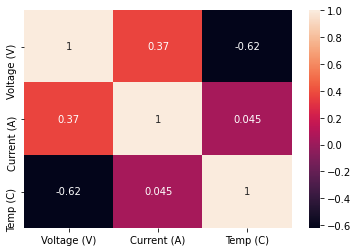

```python
import seaborn as sns

plt.figure()
sns.heatmap(X_train_SOC.corr(method='pearson'), annot=True)
plt.show()
```

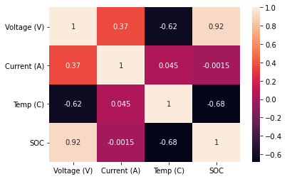

```python
plt.figure()
sns.heatmap(X_train_SOE.corr(method='pearson'), annot=True)
plt.show()
```

# **Outlier Analysis**

```python
# Importing the necessary libraries
import numpy as np
from scipy.stats import norm
```

### **For Voltage (V)**

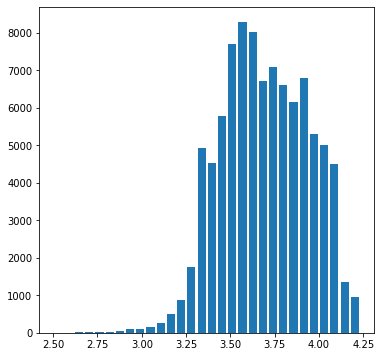

```python
plt.figure(figsize=(6,6))
plt.hist(X_train_SOC['Voltage (V)'], bins=30, rwidth=0.8)
plt.show()
```

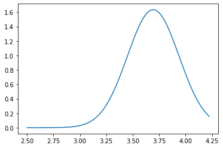

```python
rng = np.arange(X_train_SOC['Voltage (V)'].min(), X_train_SOC['Voltage (V)'].max(), 0.01)
plt.plot(rng, norm.pdf(rng, X_train_SOC['Voltage (V)'].mean(), X_train_SOC['Voltage (V)'].std()))
plt.show()
```

Removing all the data points with a z-score of greater than 3 or less than -3

```python
X_train_SOC['voltage_z_score'] = (X_train_SOC['Voltage (V)'] - X_train_SOC['Voltage (V)'].mean())/X_train_SOC['Voltage (V)'].std()

to_be_included = ((X_train_SOC['voltage_z_score']>-3) & (X_train_SOC['voltage_z_score']<3))

X_train_SOC = X_train_SOC[to_be_included]
X_train_SOE = X_train_SOE[to_be_included]
Y_train_SOC = Y_train_SOC[to_be_included]
Y_train_SOE = Y_train_SOE[to_be_included]

X_train_SOC.reset_index(level=None, drop=True, inplace=True, col_level=0, col_fill='')
Y_train_SOC.reset_index(level=None, drop=True, inplace=True)
X_train_SOE.reset_index(level=None, drop=True, inplace=True, col_level=0, col_fill='')
Y_train_SOE.reset_index(level=None, drop=True, inplace=True)

X_train_SOC.drop(['voltage_z_score'], axis=1, inplace=True)
```

### **For Current (A)**

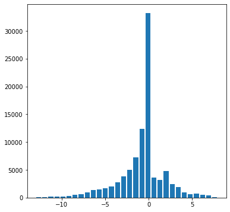

```python
plt.figure(figsize=(6,6))
plt.hist(X_train_SOC['Current (A)'], bins=30, rwidth=0.8)
plt.show()
```

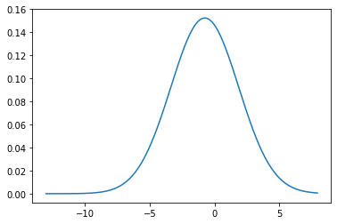

```python
rng = np.arange(X_train_SOC['Current (A)'].min(), X_train_SOC['Current (A)'].max(), 0.01)
plt.plot(rng, norm.pdf(rng, X_train_SOC['Current (A)'].mean(), X_train_SOC['Current (A)'].std()))
plt.show()
```

Removing all the data points with a z-score of greater than 3 or less than -3

```python
X_train_SOC['current_z_score'] = (X_train_SOC['Current (A)'] - X_train_SOC['Current (A)'].mean())/X_train_SOC['Current (A)'].std()

to_be_included = ((X_train_SOC['current_z_score']>-3) & (X_train_SOC['current_z_score']<3))

X_train_SOC = X_train_SOC[to_be_included]
X_train_SOE = X_train_SOE[to_be_included]
Y_train_SOC = Y_train_SOC[to_be_included]
Y_train_SOE = Y_train_SOE[to_be_included]

X_train_SOC.reset_index(level=None, drop=True, inplace=True, col_level=0, col_fill='')
Y_train_SOC.reset_index(level=None, drop=True, inplace=True)
X_train_SOE.reset_index(level=None, drop=True, inplace=True, col_level=0, col_fill='')
Y_train_SOE.reset_index(level=None, drop=True, inplace=True)

X_train_SOC.drop(['current_z_score'], axis=1, inplace=True)
```

### **For Temp (C)**

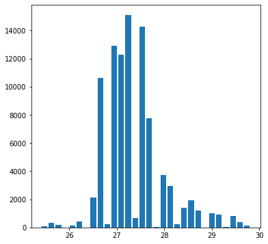

```python
plt.figure(figsize=(6,6))
plt.hist(X_train_SOC['Temp (C)'], bins=30, rwidth=0.8)
plt.show()
```

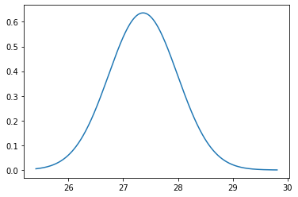

```python
rng = np.arange(X_train_SOC['Temp (C)'].min(), X_train_SOC['Temp (C)'].max(), 0.01)
plt.plot(rng, norm.pdf(rng, X_train_SOC['Temp (C)'].mean(), X_train_SOC['Temp (C)'].std()))
plt.show()
```

Removing all the data points with a z-score of greater than 3 or less than -3

```python
X_train_SOC['temp_z_score'] = (X_train_SOC['Temp (C)'] - X_train_SOC['Temp (C)'].mean())/X_train_SOC['Temp (C)'].std()

to_be_included = ((X_train_SOC['temp_z_score']>-3) & (X_train_SOC['temp_z_score']<3))

X_train_SOC = X_train_SOC[to_be_included]
X_train_SOE = X_train_SOE[to_be_included]
Y_train_SOC = Y_train_SOC[to_be_included]
Y_train_SOE = Y_train_SOE[to_be_included]

X_train_SOC.reset_index(level=None, drop=True, inplace=True, col_level=0, col_fill='')
Y_train_SOC.reset_index(level=None, drop=True, inplace=True)
X_train_SOE.reset_index(level=None, drop=True, inplace=True, col_level=0, col_fill='')
Y_train_SOE.reset_index(level=None, drop=True, inplace=True)

X_train_SOC.drop(['temp_z_score'], axis=1, inplace=True)
```

# **Tensorflow Model (SOC)**

```python
import tensorflow as tf
import keras
from tensorflow.keras.models import Sequential
from tensorflow.keras.layers import Dense, Dropout
from sklearn.metrics import mean_absolute_error
```

# **Normalizing the training and testing data**

```python
cols_to_be_normalized = ['Voltage (V)', 'Current (A)', 'Temp (C)']

for e in cols_to_be_normalized:
  mean = X_train_SOC[e].mean()
  std = X_train_SOC[e].std()
  X_train_SOC[e] = (X_train_SOC[e]-mean)/std
  X_train_SOE[e] = (X_train_SOE[e]-mean)/std

  X_test_SOC[e] = (X_test_SOC[e]-mean)/std
  X_test_SOE[e] = (X_test_SOE[e]-mean)/std
```

```python
model_SOC = Sequential()
model_SOC.add(Dense(units=5, activation='relu', input_dim=len(X_train_SOC.columns)))
model_SOC.add(Dense(units=5, activation='relu'))
model_SOC.add(Dense(units=1, activation='linear'))

es = tf.keras.callbacks.EarlyStopping(monitor='val_loss', mode='min', verbose=1, patience=50)

opt = keras.optimizers.Adam(0.001)
model_SOC.compile(loss='mse', optimizer=opt, metrics='mse')
model_SOC.summary()
```

```
Model: "sequential_2"
_________________________________________________________________
Layer (type)                 Output Shape              Param #
=================================================================
dense_6 (Dense)              (None, 5)                 20
_________________________________________________________________
dense_7 (Dense)              (None, 5)                 30
_________________________________________________________________
dense_8 (Dense)              (None, 1)                 6
=================================================================
Total params: 56
Trainable params: 56
Non-trainable params: 0
_________________________________________________________________
```

```python
model_SOC.fit(X_train_SOC, Y_train_SOC, epochs=700, batch_size=512, validation_split=0.2, validation_data=None, verbose=1, callbacks=[es])
```

```
Epoch 00181: early stopping
```

```
<tensorflow.python.keras.callbacks.History at 0x7f1f02351710>
```

```python
predictions = (model_SOC.predict(X_test_SOC))
print(mean_absolute_error(Y_test_SOC, predictions))
```

```
0.017012958412838373
```

```python
compare = pd.concat([pd.DataFrame(predictions), pd.DataFrame(Y_test_SOC)], axis=1)
compare.columns = ['Predictions', 'Actual Output']
compare
```

|  | Predictions | Actual Output |
| --- | --- | --- |
| 0 | 0.790278 | 0.788331 |
| 1 | 0.915809 | 0.912569 |
| 2 | 0.345753 | 0.353759 |
| 3 | 0.249428 | 0.253276 |
| 4 | 0.373009 | 0.371483 |
| ... | ... | ... |
| 23392 | 0.623608 | 0.625103 |
| 23393 | 0.794099 | 0.787421 |
| 23394 | 0.345132 | 0.342103 |
| 23395 | 0.198163 | 0.194517 |
| 23396 | 0.344576 | 0.337345 |

23397 rows × 2 columns

# **Tensorflow Model (SOE)**

```python
model_SOE = Sequential()
model_SOE.add(Dense(units=5, activation='relu', input_dim=len(X_train_SOE.columns)))
model_SOE.add(Dense(units=5, activation='relu'))
model_SOE.add(Dense(units=1, activation='linear'))

es = tf.keras.callbacks.EarlyStopping(monitor='val_loss', mode='min', verbose=1, patience=50)
model_SOE.compile(loss='mse', optimizer=opt, metrics='mse')
model_SOE.summary()
```

```
Model: "sequential_1"
_________________________________________________________________
Layer (type)                 Output Shape              Param #
=================================================================
dense_3 (Dense)              (None, 5)                 25
_________________________________________________________________
dense_4 (Dense)              (None, 5)                 30
_________________________________________________________________
dense_5 (Dense)              (None, 1)                 6
=================================================================
Total params: 61
Trainable params: 61
Non-trainable params: 0
_________________________________________________________________
```

```python
model_SOE.fit(X_train_SOE, Y_train_SOE, epochs=700, batch_size=512, validation_split=0.2, validation_data=None, verbose=1, callbacks=[es])
```

```
Epoch 00456: early stopping
```

```
<tensorflow.python.keras.callbacks.History at 0x7f1f00128150>
```

```python
predictions = (model_SOE.predict(X_test_SOE))
print(mean_absolute_error(Y_test_SOE, predictions))
```

```
0.0007085477290306336
```

```python
compare = pd.concat([pd.DataFrame(predictions), pd.DataFrame(Y_test_SOE)], axis=1)
compare.columns = ['Predictions', 'Actual Output']
compare
```

|  | Predictions | Actual Output |
| --- | --- | --- |
| 0 | 0.767613 | 0.768606 |
| 1 | 0.902220 | 0.902352 |
| 2 | 0.336005 | 0.335707 |
| 3 | 0.244512 | 0.242919 |
| 4 | 0.352368 | 0.352707 |
| ... | ... | ... |
| 23392 | 0.600694 | 0.600253 |
| 23393 | 0.766633 | 0.767576 |
| 23394 | 0.324048 | 0.324848 |
| 23395 | 0.191132 | 0.189838 |
| 23396 | 0.319280 | 0.320394 |

23397 rows × 2 columns

# **Saving and exporting JSON version of the model for SOC**

```python
import tensorflowjs

model_SOC.save('/content/drive/MyDrive/Colab Notebooks/Projects/SOC & SOE Estimation/Model_SOC/model_soc.h5')
tensorflowjs.converters.save_keras_model(model_SOC, '/content/drive/MyDrive/Colab Notebooks/Projects/SOC & SOE Estimation/Model_SOC/JSON')

model_SOE.save('/content/drive/MyDrive/Colab Notebooks/Projects/SOC & SOE Estimation/Model_SOE/model_soe.h5')
tensorflowjs.converters.save_keras_model(model_SOE, '/content/drive/MyDrive/Colab Notebooks/Projects/SOC & SOE Estimation/Model_SOE/JSON')
```